# CHD PheWAS follow-up: exact hits and shared comparators

MR

PheWAS

Author

Gibran Hemani

Published

October 9, 2026

This report supersedes the regional-target, per-target-complement and proxy follow-up results in `chd_example.ipynb`. That notebook is retained as historical acquisition context; none of its acquisition, metadata, LD, proxy or gene calls execute here. Every result below is recomputed from the existing local inputs.

```r
source("offline/R/offline-pipeline.R")
disable_remote_access()
source("offline/R/chd-inputs.R")
inputs <- reconstruct_chd_inputs(".")
analysis <- run_offline_analysis(inputs)
stopifnot(nrow(analysis$tables$lead_inventory) == 41L,
          nrow(analysis$comparisons) == 23L,
          length(unique(analysis$comparisons$target_snp)) == 18L,
          nrow(analysis$pooled) == 5L)
show_table <- function(x, digits = 4) knitr::kable(x, digits = digits, row.names = FALSE)
```

## Inputs and analysis policy

The **41 discovery leads** come from saved `ieu-a-7` CHD results. Follow-up uses the separate **`ukb-d-I9_IHD` outcome GWAS**. Its VCF declares `StudyType=Continuous`; the saved effect scale is unavailable. The figures therefore report saved outcome GWAS units, with no log-odds interpretation. Mediator transformations are also explicitly unknown unless documented in the local source metadata. VCF `LP` is converted from −log10(P) using `10^-LP`; missing P values remain missing.

The selected input is exactly **`chd_phewas_result.Rdata`** (singular). `chd_phewas_results.Rdata` has different contents and is not used. The selected file supplies the full lead coordinates, saved instrument identities, and the retained SNP–mediator pair inventory; its `int_chd` contains identities rather than association statistics. Indexed local mediator and outcome VCFs supply fresh beta, SE, alleles and coordinates. The compact association CSVs below are traceable derived inputs, not cached result tables.

```r
show_table(analysis$tables$extraction_counts)
```

| source | queried | found |
| --- | --- | --- |
| saved_pair_identities | 23 | 23 |
| exact_mediator_associations | 23 | 23 |
| saved_instrument_identities | 1002 | 1002 |
| instrument_vcf_associations | 1002 | 1008 |
| lead_inventory | 41 | 41 |
| outcome_query_loci | 1032 | 1032 |
| outcome_vcf_associations | 1032 | 1027 |
| outcome_leads_found | 41 | 40 |
| outcome_instruments_found | 992 | 984 |
| outcome_target_snps_found | 18 | 18 |

“Queried” counts saved requested identities; “found” counts association records or matched SNP identities as indicated by the row. The 1,002 saved instrument rows yield 1,008 VCF association records because duplicate records are retained for explicit validation. These are not 1,008 independent instruments. Outcome coverage is 40/41 leads, 984/992 distinct instrument SNPs and 18/18 retained target SNPs. Harmonisation and conflict checks determine the usable instrument counts shown below.

All 41 leads and their **inclusive ±1 Mb** regions are excluded directly from each mediator’s instruments before outcome matching and harmonisation. `rs17678683` remains in this exclusion inventory even though its outcome row is absent. Missing or conflicting exclusion coordinates cannot certify a comparator. Coordinate/build checks use the local saved coordinate system; there is no liftover or independent validation against an LD reference. Geographic windows do not establish LD independence.

Each mediator has one shared comparator, reused exactly across all of its targets, pooled MR, heterogeneity tests and decomposition. Each exact-hit estimate uses only its named SNP. Conservative harmonisation discards every A/T or C/G palindrome and rejects conflicting associations and proxy substitutions. A one-SNP comparator uses a Wald ratio; a multiple-SNP comparator uses IVW with multiplicative random effects.

## Complete discovery inventory

The 41-lead discovery inventory is distinct from the **18 retained target SNPs**, **23 unique SNP–mediator pairs** and **five mediators**. A lead without a retained mediator pair is still excluded from every comparator.

```r
show_table(analysis$tables$lead_inventory)
```

| target_snp | target_chr | target_pos | build | retained_pairs | outcome_available | followup_status |
| --- | --- | --- | --- | --- | --- | --- |
| rs10080815 | 6 | 160687412 | GRCh37 | 1 | TRUE | Retained exact follow-up pair(s) |
| rs10139550 | 14 | 100145710 | GRCh37 | 1 | TRUE | Retained exact follow-up pair(s) |
| rs10840293 | 11 | 9751196 | GRCh37 | 1 | TRUE | Retained exact follow-up pair(s) |
| rs11065979 | 12 | 112059557 | GRCh37 | 2 | TRUE | Retained exact follow-up pair(s) |
| rs11191416 | 10 | 104604916 | GRCh37 | 2 | TRUE | Retained exact follow-up pair(s) |
| rs11556924 | 7 | 129663496 | GRCh37 | 0 | TRUE | No retained saved mediator association; still excluded from every comparator |
| rs115654617 | 2 | 203893999 | GRCh37 | 1 | TRUE | Retained exact follow-up pair(s) |
| rs11838776 | 13 | 111040681 | GRCh37 | 0 | TRUE | No retained saved mediator association; still excluded from every comparator |
| rs1199338 | 3 | 138087467 | GRCh37 | 0 | TRUE | No retained saved mediator association; still excluded from every comparator |
| rs12202017 | 6 | 134173151 | GRCh37 | 0 | TRUE | No retained saved mediator association; still excluded from every comparator |
| rs1412444 | 10 | 91002927 | GRCh37 | 0 | TRUE | No retained saved mediator association; still excluded from every comparator |
| rs16986953 | 2 | 19942473 | GRCh37 | 0 | TRUE | No retained saved mediator association; still excluded from every comparator |
| rs17087335 | 4 | 57838583 | GRCh37 | 0 | TRUE | No retained saved mediator association; still excluded from every comparator |
| rs17678683 | 2 | 145286559 | GRCh37 | 0 | FALSE | No retained saved mediator association; still excluded from every comparator |
| rs180803 | 22 | 24658858 | GRCh37 | 0 | TRUE | No retained saved mediator association; still excluded from every comparator |
| rs1870634 | 10 | 44480811 | GRCh37 | 0 | TRUE | No retained saved mediator association; still excluded from every comparator |
| rs2107595 | 7 | 19049388 | GRCh37 | 1 | TRUE | Retained exact follow-up pair(s) |
| rs2128739 | 11 | 103673277 | GRCh37 | 0 | TRUE | No retained saved mediator association; still excluded from every comparator |
| rs2487928 | 10 | 30323892 | GRCh37 | 0 | TRUE | No retained saved mediator association; still excluded from every comparator |
| rs2519093 | 9 | 136141870 | GRCh37 | 1 | TRUE | Retained exact follow-up pair(s) |
| rs2681472 | 12 | 90008959 | GRCh37 | 1 | TRUE | Retained exact follow-up pair(s) |
| rs28451064 | 21 | 35593827 | GRCh37 | 0 | TRUE | No retained saved mediator association; still excluded from every comparator |
| rs2891168 | 9 | 22098619 | GRCh37 | 1 | TRUE | Retained exact follow-up pair(s) |
| rs3918226 | 7 | 150690176 | GRCh37 | 0 | TRUE | No retained saved mediator association; still excluded from every comparator |
| rs4420638 | 19 | 45422946 | GRCh37 | 2 | TRUE | Retained exact follow-up pair(s) |
| rs4468572 | 15 | 79124475 | GRCh37 | 1 | TRUE | Retained exact follow-up pair(s) |
| rs4593108 | 4 | 148281001 | GRCh37 | 0 | TRUE | No retained saved mediator association; still excluded from every comparator |
| rs515135 | 2 | 21286057 | GRCh37 | 1 | TRUE | Retained exact follow-up pair(s) |
| rs55730499 | 6 | 161005610 | GRCh37 | 1 | TRUE | Retained exact follow-up pair(s) |
| rs56062135 | 15 | 67455630 | GRCh37 | 0 | TRUE | No retained saved mediator association; still excluded from every comparator |
| rs56289821 | 19 | 11188247 | GRCh37 | 1 | TRUE | Retained exact follow-up pair(s) |
| rs56336142 | 6 | 39134099 | GRCh37 | 0 | TRUE | No retained saved mediator association; still excluded from every comparator |
| rs663129 | 18 | 57838401 | GRCh37 | 2 | TRUE | Retained exact follow-up pair(s) |
| rs6689306 | 1 | 154395946 | GRCh37 | 0 | TRUE | No retained saved mediator association; still excluded from every comparator |
| rs67180937 | 1 | 222823743 | GRCh37 | 0 | TRUE | No retained saved mediator association; still excluded from every comparator |
| rs7212798 | 17 | 59013488 | GRCh37 | 0 | TRUE | No retained saved mediator association; still excluded from every comparator |
| rs7528419 | 1 | 109817192 | GRCh37 | 1 | TRUE | Retained exact follow-up pair(s) |
| rs7568458 | 2 | 85788175 | GRCh37 | 0 | TRUE | No retained saved mediator association; still excluded from every comparator |
| rs8042271 | 15 | 89574218 | GRCh37 | 0 | TRUE | No retained saved mediator association; still excluded from every comparator |
| rs9349379 | 6 | 12903957 | GRCh37 | 2 | TRUE | Retained exact follow-up pair(s) |
| rs9970807 | 1 | 56965664 | GRCh37 | 0 | TRUE | No retained saved mediator association; still excluded from every comparator |

## Pooled mediator MR

These are the same estimates shown as “Other SNPs” in the comparison panels. Units are outcome GWAS units per the corresponding mediator GWAS unit; different mediator panels need not share an x-axis scale. Instrument F diagnostics describe the retained harmonised instruments and do not by themselves establish instrument validity.

```r
show_table(analysis$pooled[, c("mediator_id", "nsnp", "n_saved_before_exclusions",
  "n_excluded_target", "n_excluded_region", "n_retained_before_outcome_matching",
  "n_harmonised", "F_min", "F_mean", "n_weak_F", "b", "se", "pval_bh", "status")])
```

| mediator_id | nsnp | n_saved_before_exclusions | n_excluded_target | n_excluded_region | n_retained_before_outcome_matching | n_harmonised | F_min | F_mean | n_weak_F | b | se | pval_bh | status |
| --- | --- | --- | --- | --- | --- | --- | --- | --- | --- | --- | --- | --- | --- |
| ieu-b-5138 | 224 | 288 | 1 | 19 | 262 | 224 | 29.7657 | 54.7044 | 0 | 0.0020 | 0.0002 | 0.0000 | available |
| ukb-b-10831 | 7 | 11 | 0 | 2 | 9 | 7 | 31.5758 | 43.4594 | 0 | 0.0437 | 0.0139 | 0.0021 | available |
| ukb-b-2303 | 362 | 448 | 0 | 18 | 428 | 362 | 29.7628 | 64.4443 | 0 | 0.0264 | 0.0021 | 0.0000 | available |
| ukb-b-5779 | 86 | 100 | 1 | 2 | 95 | 86 | 29.7434 | 54.8531 | 0 | 0.0076 | 0.0036 | 0.0350 | available |
| ukb-d-30780_raw | 120 | 161 | 0 | 26 | 133 | 120 | 29.8525 | 96.3044 | 0 | 0.0278 | 0.0041 | 0.0000 | available |

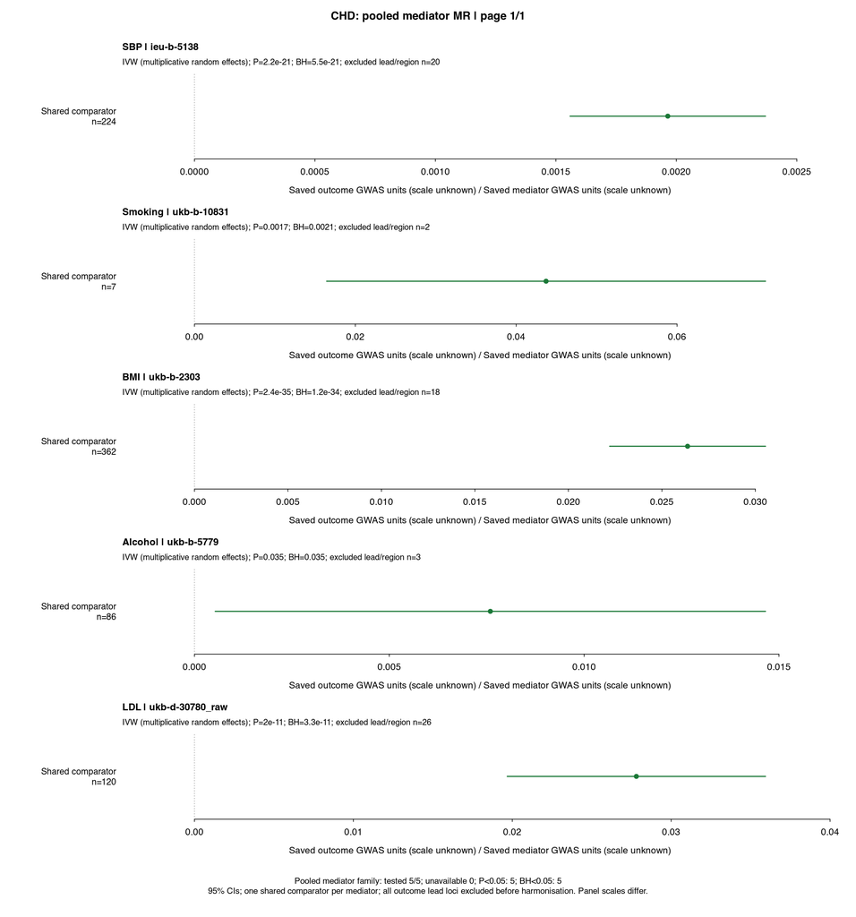

Download pooled PDF · Pooled source CSV

## Exact-hit comparisons

One panel per mediator contains every retained exact-hit row and exactly one shared comparator. Heterogeneity uses $Q=(\hat b_{\mathrm{target}}-\hat b_{\mathrm{other}})^2/(SE_{\mathrm{target}}^2+SE_{\mathrm{other}}^2)$, under a zero-covariance working assumption. BH adjustment uses available unique-pair tests. A significant Q indicates incompatibility with a common effect under the model assumptions; it does not uniquely identify a direct pathway. Nonsignificance does not establish mediation or equivalence.

```r
unavailable <- analysis$comparisons[analysis$comparisons$status != "available", ]
show_table(unavailable[, c("mediator_id", "target_snp", "target_status", "comparator_status", "reason")])
```

| mediator_id | target_snp | target_status | comparator_status | reason |
| --- | --- | --- | --- | --- |
| ieu-b-5138 | rs10139550 | unavailable | available | Target: No usable harmonised variants; n_duplicate_conflicts_outcome, n_palindromic |

```r
cat("\nAvailable comparisons:", sum(analysis$comparisons$status == "available"), "of", nrow(analysis$comparisons), ".\n")
```

```
Available comparisons: 22 of 23 .
```

The feasibility baseline was 22 usable pairs, with SBP/`rs10139550` unavailable under conservative palindrome/conflicting-association checks. The table above reports the recomputed status without forcing that count or rescuing ambiguous alleles. All 23 identities remain in the CSV and figures.

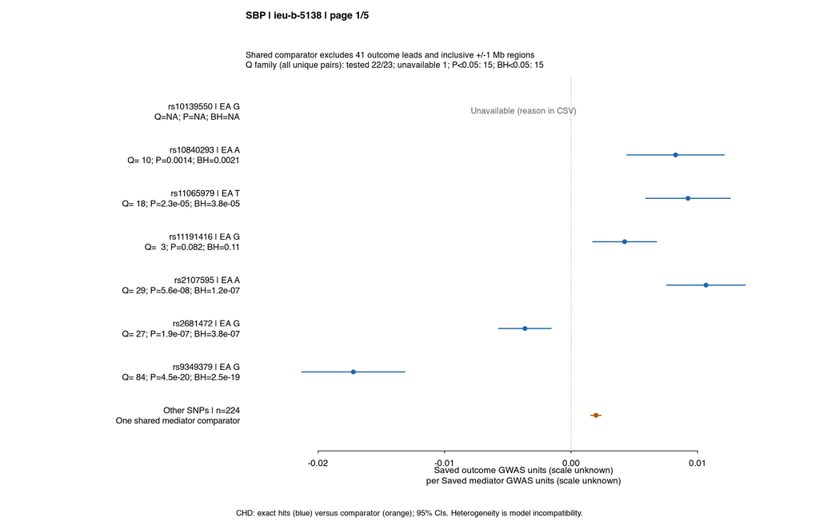

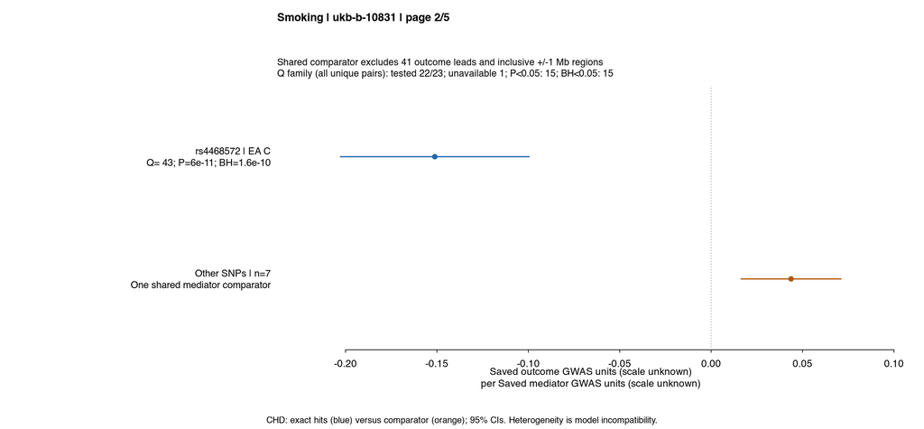

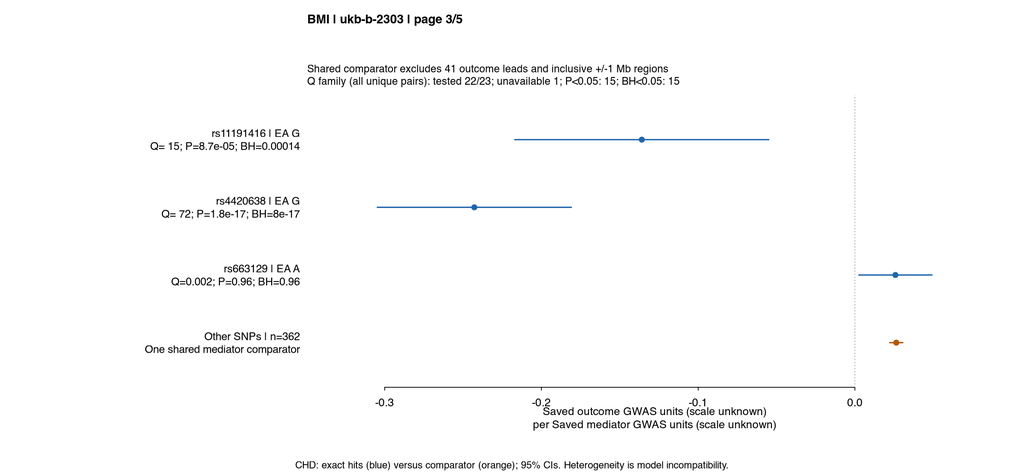

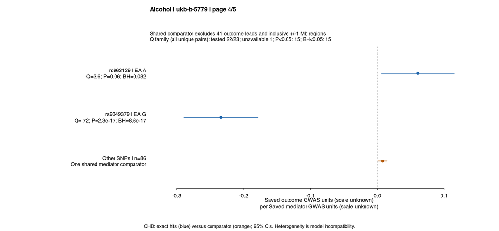

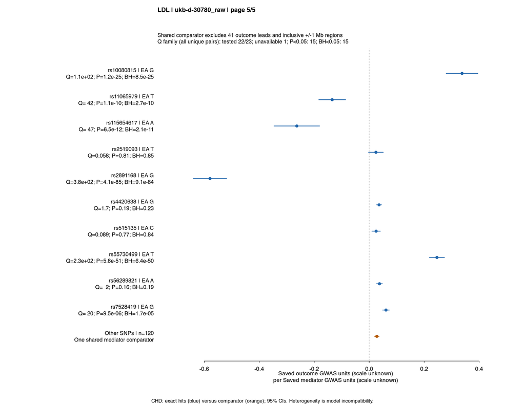

Download all comparison pages as PDF · Comparison source CSV

## Total, indirect and model-based residual components

For each pair, aligned $a$ is SNP→mediator, $t$ is SNP→outcome, and $b$ is the shared mediator→outcome comparator. The indirect component is $i=ab$ and the model-based residual is $d=t-i$. All components use outcome GWAS units per the recorded target effect allele. Signed opposing pathways are preserved; indirect effects across mediators are not summed and mediation percentages are not calculated. These residuals are not identified natural direct effects.

The primary delta method assumes zero Cov(a,b), Cov(a,t) and Cov(b,t): $\operatorname{Var}(i)=b^2\operatorname{Var}(a)+a^2\operatorname{Var}(b)$ and $\operatorname{Var}(d)=\operatorname{Var}(t)+\operatorname{Var}(i)$. Normal 95% intervals and nominal tests are approximate. Unusable components remain unavailable; an independently available total association remains visible. Instrument validity, nonlinearity, population differences and the unknown outcome scale limit causal interpretation.

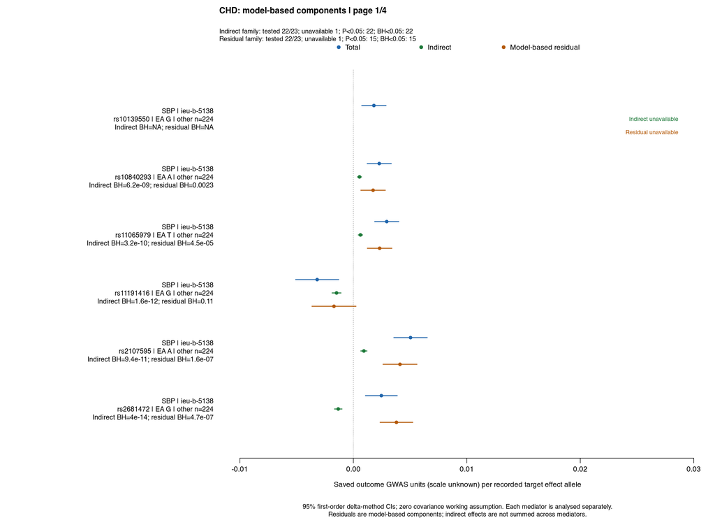

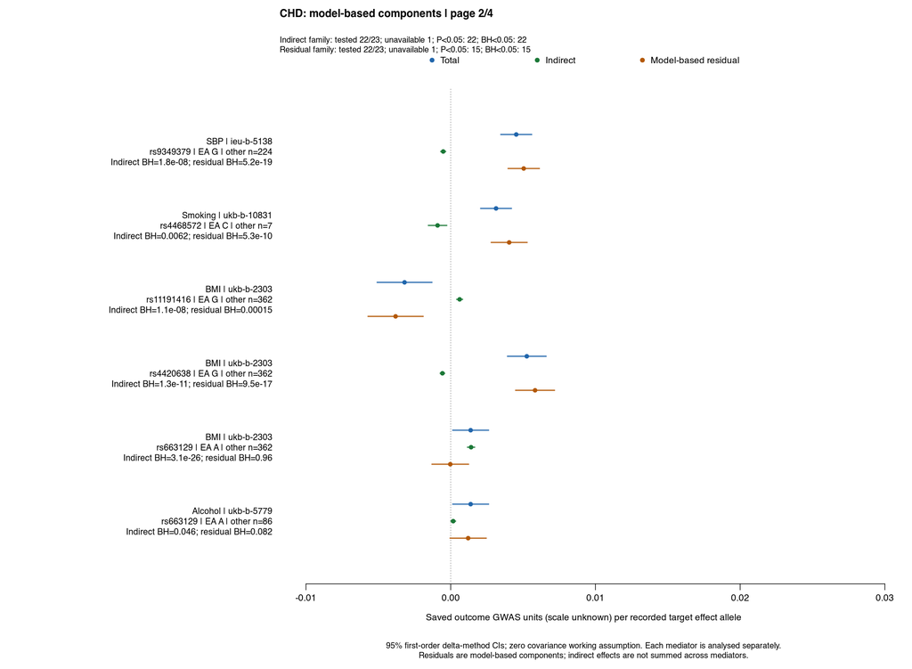

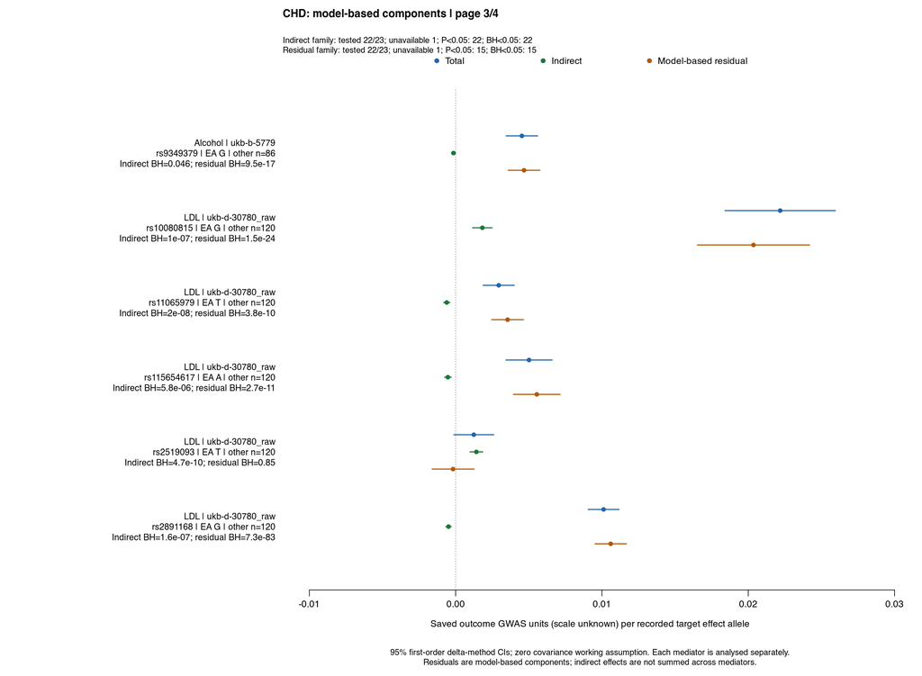

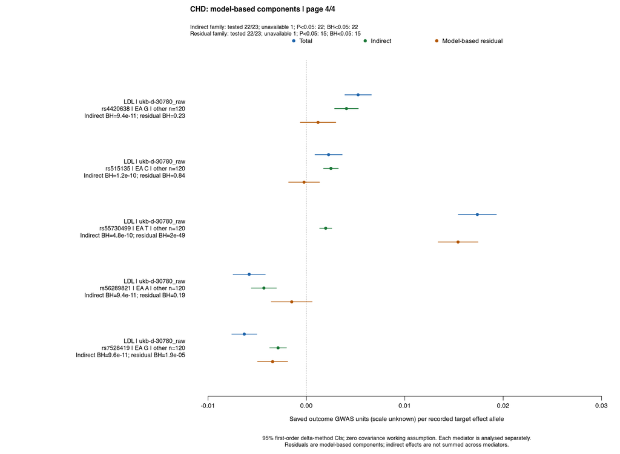

Download all decomposition pages as PDF · Decomposition source CSV

## Multiplicity and sensitivities

Primary Q, pooled MR, indirect-component and residual-component tests form **four separate BH families**. Unavailable tests do not enter a family’s tested denominator. There is no claim of joint error control across families. Each geographic and hypothetical covariance scenario has its own family.

```r
show_table(analysis$summary$families)
```

| family | inventory | tested | unavailable | nominal_below_005 | bh_below_005 |
| --- | --- | --- | --- | --- | --- |
| unique_pair_heterogeneity | 23 | 22 | 1 | 15 | 15 |
| pooled_mediator_mr | 5 | 5 | 0 | 5 | 5 |
| unique_pair_indirect_component | 23 | 22 | 1 | 22 | 22 |
| unique_pair_residual_component | 23 | 22 | 1 | 15 | 15 |
| sensitivity_pair_heterogeneity_2mb | 23 | 22 | 1 | 15 | 15 |
| sensitivity_pair_heterogeneity_2mb_mhc | 23 | 22 | 1 | 15 | 15 |
| unique_pair_indirect_component_hypothetical_rho_-0.3 | 23 | 22 | 1 | 21 | 21 |
| unique_pair_indirect_component_hypothetical_rho_0 | 23 | 22 | 1 | 22 | 22 |
| unique_pair_indirect_component_hypothetical_rho_0.3 | 23 | 22 | 1 | 21 | 21 |
| unique_pair_residual_component_hypothetical_rho_-0.3 | 23 | 22 | 1 | 15 | 15 |
| unique_pair_residual_component_hypothetical_rho_0 | 23 | 22 | 1 | 15 | 15 |
| unique_pair_residual_component_hypothetical_rho_0.3 | 23 | 22 | 1 | 16 | 15 |

The geographic sensitivity repeats the comparisons with ±2 Mb exclusions, then ±2 Mb plus extended MHC (chr6:25–34 Mb). It uses the same complete lead inventory and conservative allele policy. These are saved-coordinate sensitivities rather than verified LD/build independence checks.

The covariance sensitivity uses hypothetical equicorrelation matrices for (a,b,t), with rho = −0.3, 0 and +0.3. Each matrix is positive definite (eigenvalues 1−rho, 1−rho and 1+2rho). The propagated component SEs include the relevant covariance terms. These are illustrative assumptions, not empirical sample-overlap or covariance estimates.

Geographic sensitivity CSV · Hypothetical covariance sensitivity CSV · Family denominators CSV

## Reproduction and downloads

From the repository root, run:

```bash
cd posts/2026-05-22-phewas-example
Rscript offline/run-tests.R
Rscript offline/run-analysis.R
sh offline/render-report.sh
```

The render wrapper stages this document outside the website project, performs a fresh report-only render, and writes `chd_followup.html` beside this source. It blocks scientific remote API/download/install functions and sets loopback proxies. Local VCFs, indices and the selected Rdata must already exist; no packages or data are downloaded or installed. The shared runner also accepts normalized inputs with explicit lead inventory and outcome metadata through `run_offline_analysis(inputs, output_dir, figures_dir)`.

The repo-local statistical implementation derives from [MRCIEU/gbc-mr commit 3bbac89](https://github.com/MRCIEU/gbc-mr/tree/3bbac89e254acfbfa3385aae9b4520e4e8b5932c), with adaptations documented in `offline/README.md`. Statistical formulas live in shared modules rather than document cells. Large VCFs stay outside Git.

```r
show_table(analysis$tables$package_versions)
```

| package | version |
| --- | --- |
| R | 4.6.1 |
| TwoSampleMR | 0.7.6 |
| ieugwasr | 1.1.0.9000 |
| gwasvcf | 0.1.6 |
| GenomicRanges | 1.64.0 |
| Rsamtools | 2.28.0 |
| VariantAnnotation | 1.58.0 |
| knitr | 1.51 |
| rmarkdown | 2.31 |
| testthat | 3.3.2 |

- comparisons CSV
- pooled mr CSV
- decomposition CSV
- window sensitivity CSV
- covariance sensitivity CSV
- inference families CSV
- per snp summary CSV
- lead inventory CSV
- exact associations CSV
- instrument associations CSV
- outcome associations CSV
- provenance CSV
- extraction counts CSV
- implementation provenance CSV
- package versions CSV
- Session information
- comparisons.png
- comparisons-page-02.png
- comparisons-page-03.png
- comparisons-page-04.png
- comparisons-page-05.png
- decomposition.png
- decomposition-page-02.png
- decomposition-page-03.png
- decomposition-page-04.png
- pooled.png